# Assignment 5: Handle Missing Values

*How to do it?*:

- Open the Rmarkdown file of this assignment (link) in Rstudio.
- Right under each **question**, insert a code chunk (you can use the hotkey `Ctrl + Alt + I` to add a code chunk) and code the solution for the question.
- `Knit` the rmarkdown file (hotkey: `Ctrl + Alt + K`) to export an html.
- Publish the html file to your Githiub Page.

*Submission*: Submit the link on Github of the assignment to Canvas.

**The data:**

This assignment works with the Adult Census Data that can be downloaded at [this link.](https://bryantstats.github.io/math421/data/adult_census_missing.csv)

```r
library(VIM)
library(lubridate)
library(dplyr)
library(tidyverse)
```

**Questions**

1. Use `read_csv` to import the data. Show the number of NAs for each columns.

```r
setwd("C:/Users/student/Downloads")
census<-  read.csv('adult_census_missing.csv')
colSums(is.na(census))
```

```
##            age      workclass         fnlwgt      education  education.num
##             30              0              0              0              0
## marital.status     occupation   relationship           race            sex
##              0              0              0              0              0
##   capital.gain   capital.loss hours.per.week native.country         income
##              8              0              0              0              0
```

2. Using function `aggr` the VIM package to plot the number of NAs for each column.

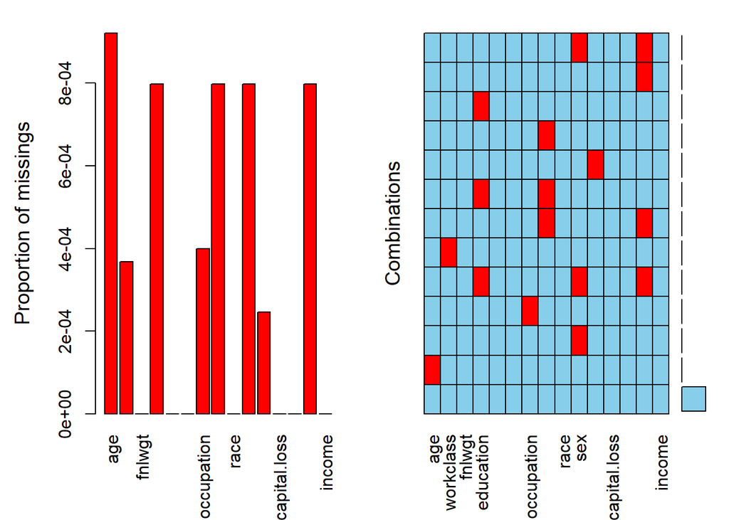

```r
library(VIM)
census <- na_if(census, 'Unknown')
census <- na_if(census, 'Missing')
census <- na_if(census, 'Not Available')
aggr(census)
```

3. Find other forms of missing values. Hint: You can use the `table` function to check if there are suspicious categories (Unknown, for example) in a variable. What all other forms of missing values shown in the data.

```r
table(census$workclass)
```

```
##
##                                 ?      Federal-gov        Local-gov
##               34             1835              957             2086
##     Never-worked        Not Known          Private     Self-emp-inc
##                7               12            22664             1110
## Self-emp-not-inc        State-gov      Without-pay
##             2537             1293               14
```

```r
table(census$education)
```

```
##
##                      10th         11th         12th      1st-4th      5th-6th
##           15          931         1174          431          168          333
##      7th-8th          9th   Assoc-acdm    Assoc-voc    Bachelors    Doctorate
##          645          514         1064         1376         5342          413
##      HS-grad      Masters    Not Known    Preschool  Prof-school Some-college
##        10475         1719           36           51          575         7273
```

```r
table(census$martial.status)
```

```
## < table of extent 0 >
```

```r
table(census$occupation)
```

```
##
##                                   ?      Adm-clerical      Armed-Forces
##                35              1840              3761                 9
##      Craft-repair   Exec-managerial   Farming-fishing Handlers-cleaners
##              4090              4059               993              1368
## Machine-op-inspct         Not Known     Other-service   Priv-house-serv
##              2001                12              3287               149
##    Prof-specialty   Protective-serv             Sales      Tech-support
##              4132               647              3647               924
##  Transport-moving
##              1594
```

```r
table(census$relationship)
```

```
##
##        Husband  Not-in-family      Not Known Other-relative      Own-child
##          13164           8287             48            979           5054
##      Unmarried           Wife
##           3439           1564
```

```r
table(census$native.country)
```

```
##
##                                                     ?
##                         15                        582
##                   Cambodia                     Canada
##                         19                        121
##                      China                   Columbia
##                         75                         59
##                       Cuba         Dominican-Republic
##                         95                         70
##                    Ecuador                El-Salvador
##                         27                        106
##                    England                     France
##                         90                         29
##                    Germany                     Greece
##                        136                         29
##                  Guatemala                      Haiti
##                         64                         44
##         Holand-Netherlands                   Honduras
##                          1                         13
##                       Hong                    Hungary
##                         20                         13
##                      India                       Iran
##                        100                         43
##                    Ireland                      Italy
##                         24                         73
##                    Jamaica                      Japan
##                         81                         62
##                       Laos                     Mexico
##                         18                        642
##                  Nicaragua                  Not Known
##                         34                         24
## Outlying-US(Guam-USVI-etc)                       Peru
##                         14                         31
##                Philippines                     Poland
##                        198                         60
##                   Portugal                Puerto-Rico
##                         37                        114
##                   Scotland                      South
##                         12                         80
##                     Taiwan                   Thailand
##                         51                         18
##            Trinadad&Tobago              United-States
##                         18                      29110
##                    Vietnam                 Yugoslavia
##                         67                         16
```

4. Replace all the forms of missing values found to NA

```r
census <- na_if(census, 'Not Known')
census <- na_if(census, '?')
```

```r
table(census$workclass)
```

```
##
##                       Federal-gov        Local-gov     Never-worked
##               34              957             2086                7
##          Private     Self-emp-inc Self-emp-not-inc        State-gov
##            22664             1110             2537             1293
##      Without-pay
##               14
```

```r
table(census$education)
```

```
##
##                      10th         11th         12th      1st-4th      5th-6th
##           15          931         1174          431          168          333
##      7th-8th          9th   Assoc-acdm    Assoc-voc    Bachelors    Doctorate
##          645          514         1064         1376         5342          413
##      HS-grad      Masters    Preschool  Prof-school Some-college
##        10475         1719           51          575         7273
```

```r
table(census$martial.status)
```

```
## < table of extent 0 >
```

```r
table(census$occupation)
```

```
##
##                        Adm-clerical      Armed-Forces      Craft-repair
##                35              3761                 9              4090
##   Exec-managerial   Farming-fishing Handlers-cleaners Machine-op-inspct
##              4059               993              1368              2001
##     Other-service   Priv-house-serv    Prof-specialty   Protective-serv
##              3287               149              4132               647
##             Sales      Tech-support  Transport-moving
##              3647               924              1594
```

```r
table(census$relationship)
```

```
##
##        Husband  Not-in-family Other-relative      Own-child      Unmarried
##          13164           8287            979           5054           3439
##           Wife
##           1564
```

```r
table(census$native.country)
```

```
##
##                                              Cambodia
##                         15                         19
##                     Canada                      China
##                        121                         75
##                   Columbia                       Cuba
##                         59                         95
##         Dominican-Republic                    Ecuador
##                         70                         27
##                El-Salvador                    England
##                        106                         90
##                     France                    Germany
##                         29                        136
##                     Greece                  Guatemala
##                         29                         64
##                      Haiti         Holand-Netherlands
##                         44                          1
##                   Honduras                       Hong
##                         13                         20
##                    Hungary                      India
##                         13                        100
##                       Iran                    Ireland
##                         43                         24
##                      Italy                    Jamaica
##                         73                         81
##                      Japan                       Laos
##                         62                         18
##                     Mexico                  Nicaragua
##                        642                         34
## Outlying-US(Guam-USVI-etc)                       Peru
##                         14                         31
##                Philippines                     Poland
##                        198                         60
##                   Portugal                Puerto-Rico
##                         37                        114
##                   Scotland                      South
##                         12                         80
##                     Taiwan                   Thailand
##                         51                         18
##            Trinadad&Tobago              United-States
##                         18                      29110
##                    Vietnam                 Yugoslavia
##                         67                         16
```

```r
remove <- drop_na(census)
```

7. Approach 2 to handle NAs: Fill all the NAs with the previous or next value. (Hint: Using `fill` function). Save the dataset after filling as a different data. The original data is unchanged (still have NAs).

```r
impute <- census %>% fill( .direction = 'updown')
```

8. Approach 3 to handle NAs: For numeric variable, replace the NAs by the median. For categorical variables, replace the NAs to the majority.

```r
median_age <- median(census$age, na.rm=TRUE)
census$age <- replace_na(census$age, median_age)
majority_class <- names(which.max(table(census$workclass)))
census$workclass <- replace_na(census$workclass, majority_class)
median_fnlwgt <- median(census$fnlwgt, na.rm=TRUE)
census$fnlwgt <- replace_na(census$fnlwgt, median_fnlwgt)
majority_edu <- names(which.max(table(census$education)))
census$education <- replace_na(census$education, majority_edu)

majority_stat <- names(which.max(table(census$marital.status)))
census$marital.status <- replace_na(census$marital.status, majority_stat)
majority_occu <- names(which.max(table(census$occupation)))
census$occupation <- replace_na(census$occupation, majority_occu)
majority_rela <- names(which.max(table(census$relationship)))
census$relationship <- replace_na(census$relationship, majority_rela)
majority_race <- names(which.max(table(census$race)))
census$race <- replace_na(census$race, majority_race)
majority_sex <- names(which.max(table(census$sex)))
census$sex <- replace_na(census$sex, majority_sex)
median_gain <- median(census$capital.gain, na.rm=TRUE)
census$capital.gain<- replace_na(census$capital.gain, median_gain)
median_loss <- median(census$capital.loss, na.rm=TRUE)
census$capital.loss<- replace_na(census$capital.loss, median_loss)
median_hrs <- median(census$hours.per.week, na.rm=TRUE)
census$hours.per.week<- replace_na(census$hours.per.week, median_hrs)
majority_country <- names(which.max(table(census$native.country)))
census$native.country <- replace_na(census$native.country, majority_country)
median_income <- median(census$income, na.rm=TRUE)
census$income<- replace_na(census$income, median_income)
```